# descriptive statisitcs: figures and tables

Tino Schneidewind

2024-11-12

This Markdown document presents some descriptive statistics about the key variables: foehn, temperature and hospitalizations. The focus lies on the distribution, the annual cycle and for hospitalizations the percentages of the subgroups.The shown data is generated by using the 8km buffer around the measurement stations.

#### figures

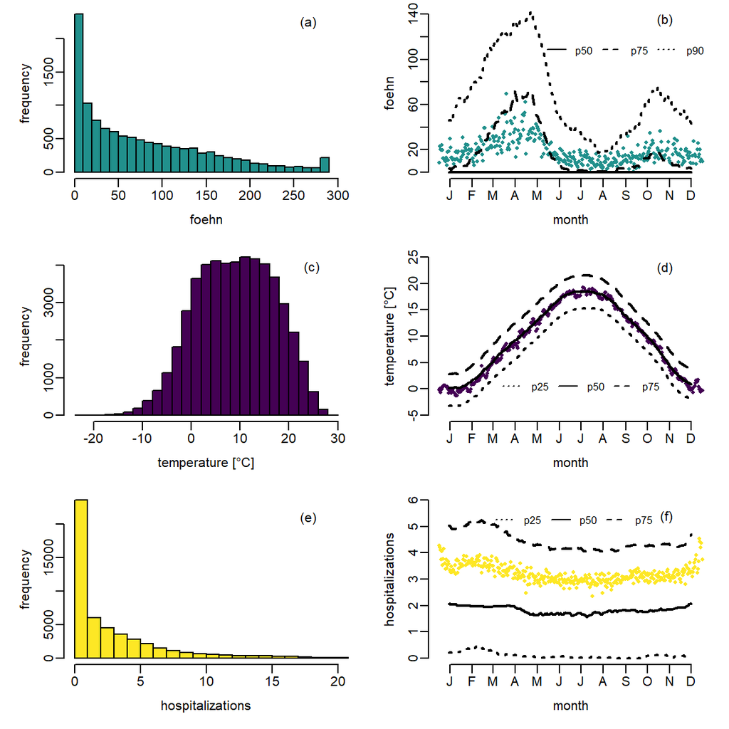

*Figure 1: (a) daily foehn score distribution excluding 0-foehn days, (b) daily mean foehn score with 30-day moving averages of the 50th, 75th, 90th percentile, (c) daily mean temperature distribution, (d) daily averages of daily mean temperature with 30-day moving averages of the 25th, 50th, 75th percentile, (e) daily all-cause hospitalization distribution, (f) daily mean all-cause hospitalizations with 30-day moving averages of the 25th, 50th, 75th percentile.*

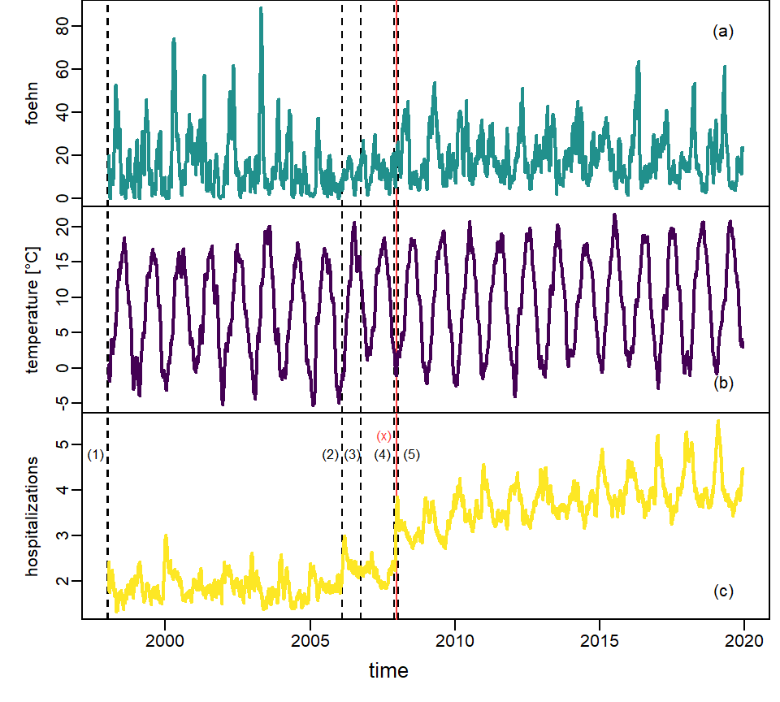

*Figure 2: (a) 30-day moving average time series of mean daily foehn, (b) 30-day moving average time series of average daily mean temperature, (c) 30-day moving average of mean daily all-cause hospitalization. (1) start of data from Altdorf, Chur, Davos, Montana, (2) start of data from Magadino, (3) start of data from Lugano, (4) start of data from Visp, (5) start of data from Poschiavo. (x) redefinition of the MedStat regions by the Swiss Federal Office for Statistics.*

#### tables

*Table 1: General information about the whole data set and hospitalization characteristics based on annual sums, ^ for multiple stations the data sets started after this date (see figure 2 or appendix table 3).*

| years | stations | start date | end date | missing days | mean hosp | sd hosp | max hosp | min hosp |
| --- | --- | --- | --- | --- | --- | --- | --- | --- |
| 141 | 8 | 1998-01-01 ^ | 2019-12-31 | 0.63 % | 1152.18 | 1304.16 | 5371 | 1 |

*Table 2: Temperature statistics in °C based on annual means and foehn statistics based on annual sums.*

| mean temp | sd temp | max temp | min temp | mean foehn | sd foehn | max foehn | min foehn |
| --- | --- | --- | --- | --- | --- | --- | --- |
| 8.99 | 3.12 | 13.94 | -1.81 | 6625.51 | 2814.43 | 17294 | 48 |

#### Appendix

*Table 3: General information per station and hospitalization characteristics per station based on annual sums.*

|  | years | start date | missing days | % of tot hosp | mean hosp | sd hosp | max hosp | min hosp |
| --- | --- | --- | --- | --- | --- | --- | --- | --- |
| Altdorf | 22 | 1998-01-01 | 0.51 % | 8.04 % | 593.50 | 154.92 | 855 | 395 |
| Chur | 22 | 1998-01-01 | 0.52 % | 23.15 % | 1709.73 | 423.66 | 2365 | 1065 |
| Davos | 22 | 1998-01-07 | 0.52 % | 2.38 % | 175.95 | 109.88 | 300 | 2 |
| Lugano | 14 | 2006-10-04 | 0.83 % | 35.54 % | 4124.43 | 1755.77 | 5371 | 1 |
| Magadino | 14 | 2006-02-15 | 0.79 % | 14.02 % | 1626.50 | 265.53 | 1986 | 1154 |
| Montana | 22 | 1998-01-07 | 0.5 % | 12.15 % | 897.09 | 709.38 | 1772 | 112 |
| Poschiavo | 12 | 2008-01-23 | 0.92 % | 0.78 % | 106.17 | 20.64 | 135 | 79 |
| Visp | 13 | 2007-11-30 | 1.13 % | 3.94 % | 491.77 | 156.68 | 616 | 9 |

*Table 4: Contribution in percent of different subgroups to all-cause hospitalizations counts across all stations and per station. Brackets indicate which columns sum up to 100 % per station*

|  | (male | female) | (age <= 64 | age > 64) | (cvd | resp | inf | uri | ment) |
| --- | --- | --- | --- | --- | --- | --- | --- | --- | --- |
| all | 53.92 % | 46.08 % | 47.6 % | 52.4 % | 33.91 % | 22.11 % | 12.08 % | 15.04 % | 16.87 % |
| Altdorf | 55.75 % | 44.25 % | 46.89 % | 53.11 % | 40.19 % | 18.15 % | 14.78 % | 12.64 % | 14.24 % |
| Chur | 53.96 % | 46.04 % | 57.48 % | 42.52 % | 31.18 % | 21.71 % | 12.9 % | 14.69 % | 19.53 % |
| Davos | 51.69 % | 48.31 % | 51.92 % | 48.08 % | 33.27 % | 21.8 % | 15.53 % | 13.98 % | 15.42 % |
| Lugano | 53.2 % | 46.8 % | 40.11 % | 59.89 % | 35.89 % | 23.11 % | 11.03 % | 16.4 % | 13.58 % |
| Magadino | 54.53 % | 45.47 % | 44.64 % | 55.36 % | 33.79 % | 23.74 % | 11.83 % | 16.28 % | 14.36 % |
| Montana | 54.13 % | 45.87 % | 52.11 % | 47.89 % | 30.84 % | 20.28 % | 9.91 % | 11.86 % | 27.1 % |
| Poschiavo | 53.77 % | 46.23 % | 40.66 % | 59.34 % | 34.77 % | 23.08 % | 8.71 % | 14.44 % | 19 % |
| Visp | 55 % | 45 % | 53.87 % | 46.13 % | 29.34 % | 23.24 % | 17.41 % | 15.88 % | 14.12 % |

*Table 5: Temperature statistics in °C per station based on annual means and foehn statistics per station based on annual sums.*

|  | mean temp | sd temp | max temp | min temp | % of tot foehn | mean foehn | sd foehn | max foehn | min foehn |
| --- | --- | --- | --- | --- | --- | --- | --- | --- | --- |
| Altdorf | 10.50 | 0.52 | 11.66 | 9.62 | 13.64 % | 5791.32 | 1373.51 | 8483 | 3689 |
| Chur | 10.51 | 0.61 | 11.95 | 9.44 | 15.6 % | 6623.50 | 1429.21 | 9092 | 4260 |
| Davos | 4.11 | 0.60 | 5.06 | 2.76 | 12.26 % | 5207.32 | 1442.08 | 8751 | 2720 |
| Lugano | 13.08 | 1.10 | 13.94 | 9.69 | 7.92 % | 5283.36 | 1873.88 | 7781 | 666 |
| Magadino | 12.31 | 0.57 | 13.58 | 11.44 | 9.28 % | 6192.00 | 1383.05 | 8843 | 3964 |
| Montana | 6.43 | 0.65 | 7.54 | 5.12 | 14.97 % | 6356.32 | 2521.34 | 11690 | 3142 |
| Poschiavo | 8.01 | 0.50 | 8.56 | 6.79 | 17.31 % | 13473.33 | 2455.41 | 17294 | 9804 |
| Visp | 9.40 | 3.41 | 11.32 | -1.81 | 9.03 % | 6487.38 | 2244.62 | 8831 | 48 |

*Table 6: Abbreviation and location of meteorological measurement stations and their assigned MedStat regions within an 8 km buffer.*

|  | Altdorf | Chur | Davos | Lugano | Magadino | Montana | Poschiavo | Visp |
| --- | --- | --- | --- | --- | --- | --- | --- | --- |
| Abbreviation | ALT | CHU | DAV | LUG | MAG | MVE | ROB | VIS |
| X Coordinate | 46.887042 | 46.870622 | 46.812956 | 46.003833 | 46.160019 | 46.298772 | 46.347194 | 46.302875 |
| Y Coordinate | 8.621806 | 9.530814 | 9.843492 | 8.960117 | 8.933608 | 7.460761 | 10.062964 | 7.842903 |
| 1 MedStat regions | UR01 | GR01 | GR09 | TI20 | TI16 | VS12 | GR25 | VS09 |
| 2 | UR02 | GR04 |  | TI21 | TI06 | VS15 |  | VS06 |
| 3 | UR03 | GR03 |  | TI22 | TI15 | VS16 |  |  |
| 4 |  |  |  | TI25 | TI07 | VS19 |  |  |
| 5 |  |  |  | TI27 | TI17 | VS13 |  |  |
| 6 |  |  |  | TI18 |  |  |  |  |
| 7 |  |  |  | TI23 |  |  |  |  |
| 8 |  |  |  | TI19 |  |  |  |  |
| 9 |  |  |  | TI28 |  |  |  |  |
| 10 |  |  |  | TI29 |  |  |  |  |
| 11 |  |  |  | TI26 |  |  |  |  |
| 12 |  |  |  | TI24 |  |  |  |  |